# Solutions for 25. Nested Models & F-Tests

Notes and in-class exercises

## Exercise 1: Nested Models

1. Models 1, 2, 4 and 6.
- Model 1 is nested in Model 2 TRUE
- Model 1 is nested in Model 3 TRUE
- Model 1 is nested in Model 4 FALSE
- Model 2 is nested in Model 3 TRUE
- Model 3 is nested in Model 2 FALSE
- Model 2 is nested in Model 6 FALSE
3. You could compare the Adjusted $R^2$ values from each model, and note that the one with a higher adjusted $R^2$ is better by this metric. Multiple $R^2$ would *not* be a good metric, because the larger model (within the nesting structure) will *always* have a higher $R^2$ value.

## Exercise 2: F-Tests

```r
# load necessary packages
library(ggplot2)
library(dplyr)
library(readr)

# load datasets
MacGrades <- read_csv("https://mac-stat.github.io/data/MacGrades.csv")
```

1. It is reasonable to assume that course grade varies by department as well as course level and instructor. Certain instructors may grade more strictly (or curve more) than others, and similarly, this can vary across department due to cultural norms within the department. As the level of a course gets higher, I would expect grades to perhaps get lower, since courses with higher numbers are expected to be more difficult. Then again, students perhaps “care” more about such courses, and may put in more effort to get a higher grade. I doubt semester plays a significant role in determining course grades, though it is possible that Fall semester first-years or Spring semester seniors have worse grades, on average. We don’t have course year as a variable in our data, so we would be unable to examine this relationship. As enrollment in a course goes up, I would expect grades to decrease, since professors have less time to dedicate to individual students when course enrollment is high.
2. Explore the relationship between course grades and other variables in the data. Make at least four visualizations, *and* describe any patterns you observe.

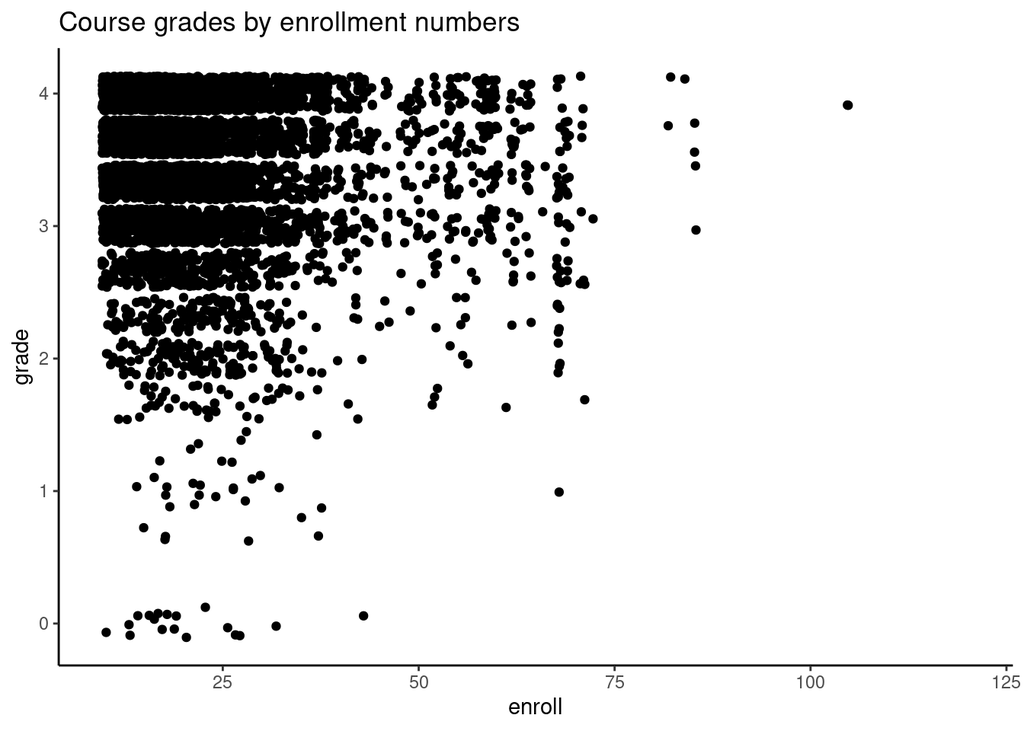

```r
library(stringr)
# Exploratory plots

# course grade vs. enrollment
MacGrades %>%
  ggplot(aes(enroll, grade)) +
  geom_jitter() +
  theme_classic() +
  ggtitle("Course grades by enrollment numbers")
```

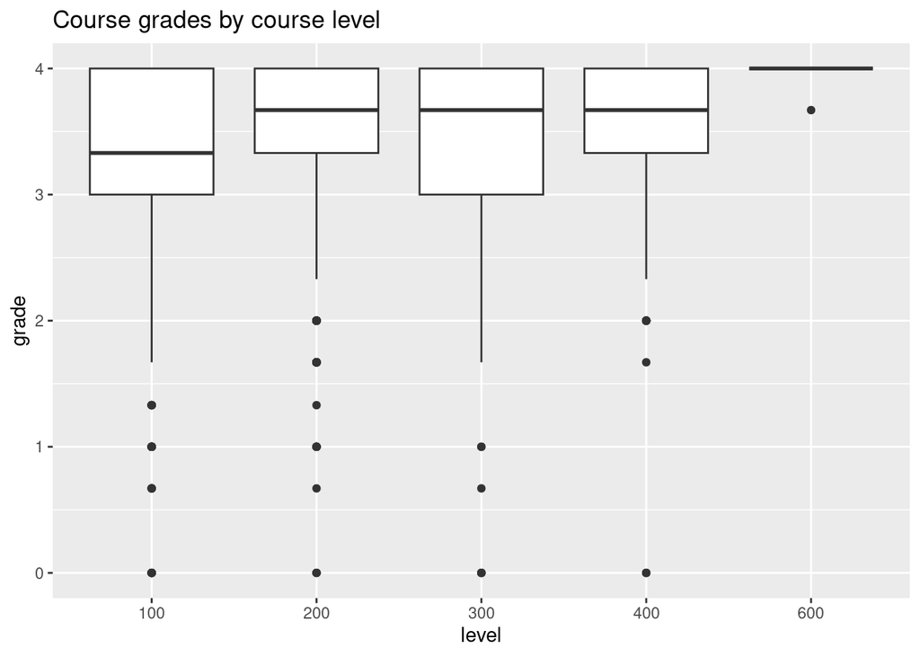

```r
# course grade vs. level
MacGrades %>%
  mutate(level = factor(level)) %>%
  ggplot(aes(y = grade, x = level)) +
  geom_boxplot() +
  ggtitle("Course grades by course level")
```

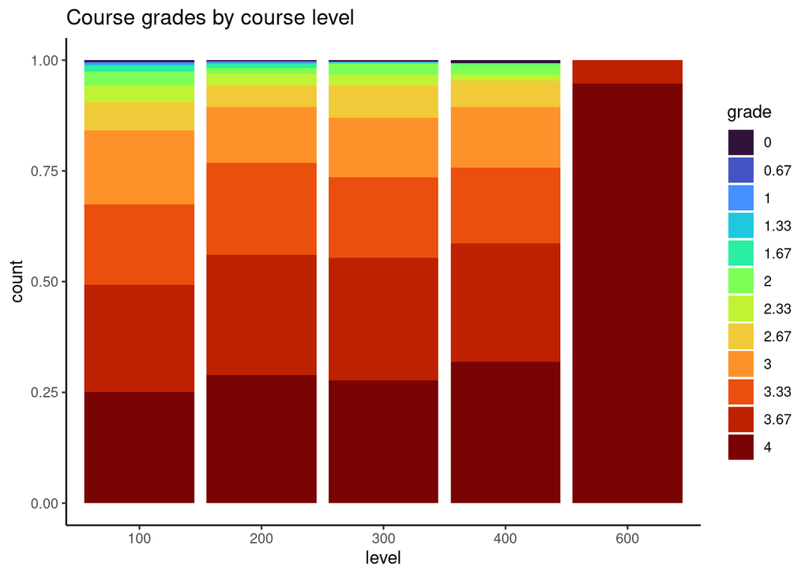

```r
# course grade vs. level (treating grade as categorical)
MacGrades %>%
  filter(!is.na(grade)) %>%
  mutate(level = factor(level),
         grade = factor(grade)) %>%
  ggplot(aes(x = level, fill = grade)) +
  geom_bar(position = "fill") +
  scale_fill_viridis_d(option = "H") +
  theme_classic() +
  ggtitle("Course grades by course level")
```

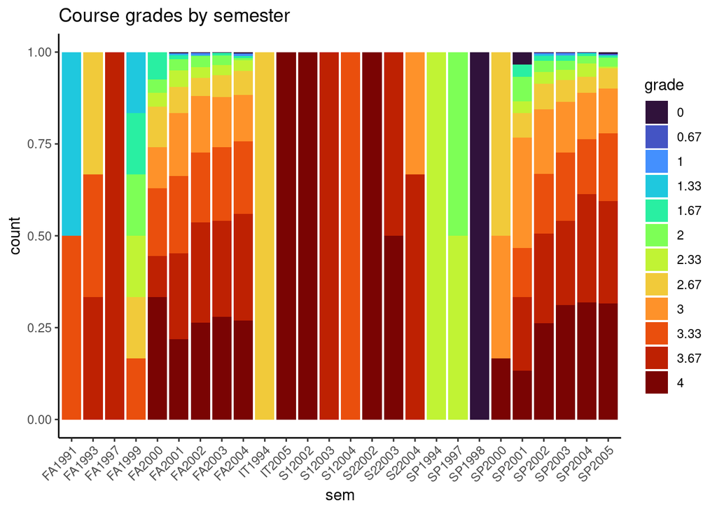

```r
# course grade vs. semester
MacGrades %>%
  filter(!is.na(grade)) %>%
  mutate(grade = factor(grade)) %>%
  ggplot(aes(x = sem, fill = grade)) +
  geom_bar(position = "fill") +
  scale_fill_viridis_d(option = "H") +
  theme_classic() +
  ggtitle("Course grades by semester") +
  theme(axis.text.x = element_text(angle = 45, hjust = 1))
```

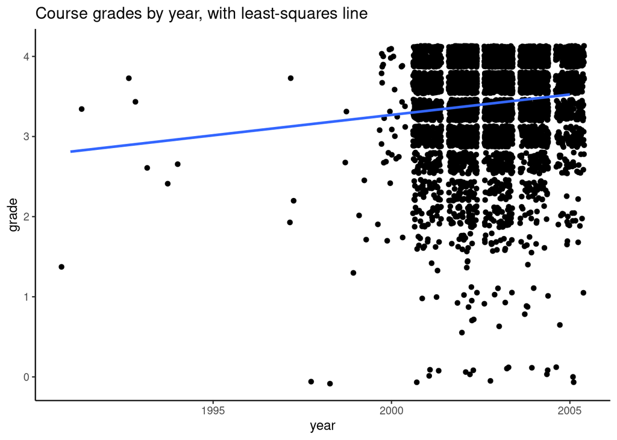

```r
# Let's do something fancy and check out how grades have changed over time... this will require
# some string manipulation

MacGrades$year <- MacGrades$sem %>%
  str_replace("FA", "") %>%
  str_replace("SP", "") %>%
  str_replace("S1", "") %>%
  str_replace("S2", "") %>%
  str_replace("IT", "") %>% as.numeric()

MacGrades %>%
  ggplot(aes(year, grade)) +
  geom_jitter() +
  geom_smooth(method = "lm", se = FALSE) +
  theme_classic() +
  ggtitle("Course grades by year, with least-squares line")
```

In general, course grades seem to be associated with enrollment numbers. Specifically, when enrollments are greater than 50, we see very few students receiving a course grade lower than a 2.0, which is different than when enrollments are fewer than 50 students. There does not appear to be a clear relationship between course grade and course level, with the exception of 600-level courses. In these cases, every student received either an A or A-. It does seem like the proportion of students who received lower than a 2.67 is greater for 100-level courses than the other course levels.

```r
# Make level categorical
MacGrades <- MacGrades %>%
  mutate(level = factor(level))
```

```r
mod <- lm(grade ~ level, data = MacGrades)
summary(mod)
```

```
Call:
lm(formula = grade ~ level, data = MacGrades)

Residuals:
    Min      1Q  Median      3Q     Max
-3.4776 -0.3492  0.2089  0.5224  0.6508

Coefficients:
            Estimate Std. Error t value Pr(>|t|)
(Intercept)  3.34924    0.01208 277.166  < 2e-16 ***
level200     0.11183    0.01995   5.606 2.17e-08 ***
level300     0.09078    0.01949   4.659 3.25e-06 ***
level400     0.12835    0.03168   4.052 5.15e-05 ***
level600     0.63339    0.13624   4.649 3.41e-06 ***
---
Signif. codes:  0 '***' 0.001 '**' 0.01 '*' 0.05 '.' 0.1 ' ' 1

Residual standard error: 0.5915 on 5704 degrees of freedom
  (437 observations deleted due to missingness)
Multiple R-squared:  0.01085,   Adjusted R-squared:  0.01016
F-statistic: 15.65 on 4 and 5704 DF,  p-value: 9.713e-13
```

5. State the null and alternative hypotheses associated with the research question in part (d).

$$H_0: \beta_1 = \beta_2 = \beta_3 = \beta_4 = 0$$

$$H_1: \text{One of } \beta_1, \beta_2, \beta_3, \beta_4 \neq 0$$
In words, the null is that there is *no* relationship between course level and course grades, and the alternative is that there is *some* relationship (either positive or negative) between course level and course grades.

6. The p-value associated with this hypothesis test is 9.713 x $10^{-13}$. We do have enough evidence to reject the null hypothesis.

```r
mod <- lm(grade ~ enroll, data = MacGrades)
summary(mod)
```

```
Call:
lm(formula = grade ~ enroll, data = MacGrades)

Residuals:
    Min      1Q  Median      3Q     Max
-3.4529 -0.3871  0.2265  0.5534  0.8448

Coefficients:
              Estimate Std. Error t value Pr(>|t|)
(Intercept)  3.4842350  0.0173790 200.485  < 2e-16 ***
enroll      -0.0031336  0.0006683  -4.689 2.81e-06 ***
---
Signif. codes:  0 '***' 0.001 '**' 0.01 '*' 0.05 '.' 0.1 ' ' 1

Residual standard error: 0.5934 on 5707 degrees of freedom
  (437 observations deleted due to missingness)
Multiple R-squared:  0.003838,  Adjusted R-squared:  0.003664
F-statistic: 21.99 on 1 and 5707 DF,  p-value: 2.806e-06
```

$$H_0: \beta_1 = 0$$

$$H_1: \beta_1 \neq 0$$

1. The p-value associated with this hypothesis test is 2.806 x $10^{-06}$. We do have enough evidence to reject the null hypothesis. Note that this p-value could be obtained from either the overall model fit or from the individual coefficient for enroll (they are the same). They may be ever so slightly different when there are few observations in your dataset, but when there are a lot, they will be exactly identical.
10. We do *not* need to conduct an F-test, because our hypothesis test involves only a single regression coefficient, and therefore is readily obtained from the summary output of our linear model in R.

## Exercise 3: More F-tests

$$E[grade | enroll, level] = \beta_0 + \beta_1 enroll + \beta_2 level200 + \beta_3 level300 + \beta_4 level400 + \beta_5 level600$$

The relevant coefficient that answers our scientific question is $\beta_1$, or the coefficient that corresponds to enrollment.

The relevant null and alternative hypotheses are:

$$H_0: \beta_1 = 0$$
$$H_1: \beta_1 \neq 0$$
We do not need to conduct an F-test to complete this hypothesis testing procedure, since our hypothesis involves only a single regression coefficient.

```r
mod <- lm(grade ~ enroll + level, data = MacGrades)
summary(mod)
```

```
Call:
lm(formula = grade ~ enroll + level, data = MacGrades)

Residuals:
    Min      1Q  Median      3Q     Max
-3.4916 -0.3481  0.1907  0.5162  0.7764

Coefficients:
              Estimate Std. Error t value Pr(>|t|)
(Intercept)  3.4091632  0.0219143 155.568  < 2e-16 ***
enroll      -0.0022628  0.0006907  -3.276 0.001058 **
level200     0.1040873  0.0200701   5.186 2.22e-07 ***
level300     0.0743387  0.0201066   3.697 0.000220 ***
level400     0.1118660  0.0320492   3.490 0.000486 ***
level600     0.6182478  0.1361974   4.539 5.76e-06 ***
---
Signif. codes:  0 '***' 0.001 '**' 0.01 '*' 0.05 '.' 0.1 ' ' 1

Residual standard error: 0.591 on 5703 degrees of freedom
  (437 observations deleted due to missingness)
Multiple R-squared:  0.01271,   Adjusted R-squared:  0.01185
F-statistic: 14.69 on 5 and 5703 DF,  p-value: 2.453e-14
```

We have statistically significant evidence of a relationship between enrollment and course grade, for courses of the same level (p = 0.001058). We reject the null hypothesis that there is no relationship between enrollment and course grade, adjusting for course level.

## Exercise 4

Our model statement is identical to that in Exercise 3, but the relevant coefficients are $\beta_2, \beta_3, \beta_4$, and $\beta_5$.

The relevant null and alternative hypotheses are:

$$H_0: \beta_2 = \beta_3 = \beta_4 = \beta_5 = 0$$

$$H_1: \text{At least one of } \beta_2, \beta_3, \beta_4, \beta_5 \neq 0$$

We *do* need to conduct an F-test to complete this hypothesis testing procedure, since our hypothesis involves more than one regression coefficient.

```r
# Same model as in Question 10, we just now need to do an F-test!
mod <- lm(grade ~ enroll + level, data = MacGrades)
smaller_mod <- lm(grade ~ enroll, data = MacGrades)

anova(smaller_mod, mod)
```

```
Analysis of Variance Table

Model 1: grade ~ enroll
Model 2: grade ~ enroll + level
  Res.Df    RSS Df Sum of Sq      F   Pr(>F)
1   5707 2009.8
2   5703 1991.9  4    17.904 12.815 2.19e-10 ***
---
Signif. codes:  0 '***' 0.001 '**' 0.01 '*' 0.05 '.' 0.1 ' ' 1
```

We have statistically significant evidence of a relationship between course level and course grade, for courses of the same enrollment ($p = 2.19 \times 10^{-10}$). We reject the null hypothesis that there is no relationship between course level and course grade, adjusting for enrollment.

## Exercise 5: Reference categories

H0: There is no relationship between course grade and department.

H1: There is *some* relationship between course grade and department.

```r
mod <- lm(grade ~ dept, data = MacGrades)
summary(mod)
```

```
Call:
lm(formula = grade ~ dept, data = MacGrades)

Residuals:
    Min      1Q  Median      3Q     Max
-3.5268 -0.2749  0.1475  0.4515  0.9039

Coefficients:
              Estimate Std. Error t value Pr(>|t|)
(Intercept)  3.5000000  0.4088676   8.560   <2e-16 ***
deptb       -0.2536066  0.4155163  -0.610    0.542
deptB       -0.2614286  0.4278948  -0.611    0.541
deptC        0.0268398  0.4106338   0.065    0.948
deptd       -0.1825995  0.4098240  -0.446    0.656
deptD        0.0617623  0.4105399   0.150    0.880
depte       -0.0162500  0.4122607  -0.039    0.969
deptE        0.1391667  0.4416275   0.315    0.753
deptF       -0.2251373  0.4104679  -0.548    0.583
deptg        0.0956522  0.4176615   0.229    0.819
deptG       -0.3303306  0.4105537  -0.805    0.421
deptH       -0.0307813  0.4120495  -0.075    0.940
depti       -0.1474011  0.4111711  -0.358    0.720
deptI        0.0011538  0.4243020   0.003    0.998
deptj       -0.0625248  0.4108867  -0.152    0.879
deptJ       -0.2815172  0.4116777  -0.684    0.494
deptk        0.0124521  0.4104311   0.030    0.976
deptK       -0.2431624  0.4123474  -0.590    0.555
deptL        0.0468000  0.4169648   0.112    0.911
deptm        0.0224798  0.4099682   0.055    0.956
deptM       -0.4039440  0.4099067  -0.985    0.324
deptn        0.1487363  0.4111080   0.362    0.718
deptN        0.1670000  0.4139469   0.403    0.687
depto       -0.3616667  0.4255629  -0.850    0.395
deptO        0.0066856  0.4100242   0.016    0.987
deptp       -0.0139370  0.4120744  -0.034    0.973
deptP       -0.1140000  0.4249077  -0.268    0.788
deptq        0.0001132  0.4104076   0.000    1.000
deptQ       -0.0644094  0.4120744  -0.156    0.876
deptR       -0.0381579  0.4110139  -0.093    0.926
depts       -0.0154839  0.4218507  -0.037    0.971
deptS       -0.0247500  0.4139469  -0.060    0.952
deptt       -0.0126923  0.4166562  -0.030    0.976
deptT       -0.2733962  0.4165106  -0.656    0.512
deptU       -0.1136842  0.4298486  -0.264    0.791
deptV       -0.0242500  0.4189646  -0.058    0.954
deptW       -0.0507164  0.4100863  -0.124    0.902
deptX       -0.1189865  0.4116209  -0.289    0.773
deptY        0.0814894  0.4174763   0.195    0.845
---
Signif. codes:  0 '***' 0.001 '**' 0.01 '*' 0.05 '.' 0.1 ' ' 1

Residual standard error: 0.5782 on 5670 degrees of freedom
  (437 observations deleted due to missingness)
Multiple R-squared:  0.06037,   Adjusted R-squared:  0.05407
F-statistic: 9.586 on 38 and 5670 DF,  p-value: < 2.2e-16
```

We have statistically significant evidence of a relationship between department and course grades at a significance level of 0.05 (p-value < 2.2 x $10^{-16}$). We reject the null hypothesis that there is no relationship between course grade and department.

*None* of the individual p-values for department are significant! These p-values tell us about whether or not there is a statistically significant difference in course grades between each respective department and the *reference* department (Department “A”). This doesn’t contradict our answer to part (b) because there are different hypothesis tests that answer different questions!